# WTI Options Portfolio: Full Greek P&L Attribution

Individual Project

Author

Will Thompson

Published

March 6, 2026

# Description

You are a risk analyst at an energy trading desk. The desk holds a portfolio of WTI crude oil options — specifically, options on NYMEX CL futures contracts.

Your role is to:

- Build a full-Greek P&L attribution framework: the standard tool used on trading desks to explain daily P&L movements across **Delta** (directional exposure), **Gamma** (curvature), **Vega** (volatility sensitivity), **Vanna** (sensitivity of delta to volatility), and **Theta** (time decay).
- You are expected to understand contracts and use the right option model and specifications in the `RTL` package.
- Tell me in your own words the portfolio’s risk profile, how the Greeks interact, and what this means for a desk managing this book in practice.
- No AI use in any shape or form and assignment submitted should be a github repo that I can clone and assess.

# Objective

1. Compute numerical Greeks for each position and for the overall portfolio across the full WTI price range ($50–$100/bbl).
2. Interpret the portfolio’s mark-to-market profile and explain how changing Gamma across strike levels affects delta-hedging in practice.
3. Build a complete P&L attribution framework — Delta, Gamma, Vega, Vanna, and Theta — and verify it accurately explains overnight P&L under a realistic market move.
4. Critically evaluate where and why the linear/quadratic approximation breaks down as spot moves away from current market.

# Exposure

WTI Options Portfolio

Three-way collar: long put spread + short OTM call | F₀ = $73/bbl

| Position | Type | Strike K ($/bbl) | Maturity | Impl. Vol | Contracts |
| --- | --- | --- | --- | --- | --- |
| P1 | Put | 70.00 | 3M | 35.00% | +2,000 long |
| P2 | Put | 55.00 | 3M | 42.00% | -2,000 short |
| P3 | Call | 80.00 | 3M | 30.00% | -2,000 short |

**Market parameters**: current WTI futures price F₀ = **$73.00/bbl**, risk-free rate r = **4.00%** (annualised, continuously compounded).

Select the appropriate pricing model from the `RTL` package for options on WTI crude oil futures. Consider the nature of the underlying contract — a NYMEX CL futures — when choosing the model and setting its cost-of-carry parameter.

# Question 1 (9 points)

For **each position**, compute the following Greeks **numerically** using central differences evaluated at `F_0`:

- **Delta** (∂V/∂F)
- **Gamma** (∂²V/∂F²)
- **Vega** (∂V/∂σ)
- **Theta** (∂V/∂T)

**Step size selection**: For each Greek, choose an appropriate finite-difference step size and explain your reasoning. A good step is small enough that the finite difference accurately approximates the true derivative, but not so small that floating-point subtraction errors dominate. Consider the natural scale of each risk factor (price in $/bbl, vol as a decimal, time in years) and any special considerations for the short-dated options in this portfolio.

**Dollar scaling**: Each raw numerical derivative gives the option price change **per barrel** for a unit move in the risk factor. To express the Greek as a total dollar P&L impact for a position, multiply by `n × mult`, where `n` is the signed contract count (positive = long, negative = short) and `mult = 1,000 bbl/contract`. For example, a delta of 0.50/bbl for a 3,000-contract long position means the desk gains or loses 0.50 × 3,000 × 1,000 = $1,500,000 per $1/bbl move in WTI.

Create plots showing each Greek vs. futures price over F ∈ [50, 100], with one line per position.

**d.** Compute the **portfolio mark-to-market (MTM)** value and **portfolio Gamma** across F ∈ [50, 100]. Plot them on two separate panels. In 3–5 sentences, explain:

- What the MTM profile shape reveals about the portfolio’s net directionality and curvature.
- Where portfolio Gamma is highest and lowest across the price range, and why those regions correspond to specific positions.
- What the changing Gamma means for a delta-hedger rebalancing daily as WTI moves through the $50–$100 range.

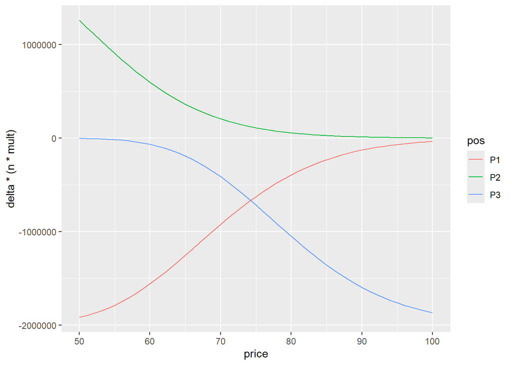

```r
#Initializing dividend as 0

#Since we are dealing with futures contracts we will not be using BSM, instead we will use Black 76
#The numerical difference is that our cost of carry (r - d) will be set to 0, so we will initialize b = 0 and remove b = r - d
b = 0


#This function will be used to calculate delta using the numerical method
numericaldelta <- function(price, type, K, T2M, sigma){
  step.delta = 0.1

  p.down <- RTL::GBSOption(price - step.delta, K , T2M, r , b = 0, sigma = sigma, type = type)$price
  p.up <-RTL::GBSOption(price + step.delta, K , T2M, r , b = 0, sigma = sigma, type = type)$price

  delta.numerical <- (p.up - p.down) / (2 * step.delta)
  delta.numerical
  }



numericalgamma <- function(price, type, K, T2M, sigma){
  step.gamma = 0.1

  p.down <- RTL::GBSOption(price - step.gamma, K , T2M, r , b = 0, sigma = sigma, type = type)$price
  p.current <- RTL::GBSOption(price, K , T2M, r , b = 0, sigma = sigma, type = type)$price
  p.up <-RTL::GBSOption(price + step.gamma, K , T2M, r , b = 0, sigma = sigma, type = type)$price

  gamma.numerical <- (p.up - 2 * p.current + p.down) / step.gamma ^ 2
  gamma.numerical
  }



numericalvega <- function(price, type, K, T2M, sigma){
  step.vega = 0.01

  p.down <- RTL::GBSOption(price, K , T2M, r , b = 0, sigma = sigma - step.vega, type = type)$price
  p.up <-RTL::GBSOption(price, K , T2M, r , b = 0, sigma = sigma + step.vega, type = type)$price

  vega.numerical <- (p.up - p.down) / 2 * step.vega * 100
  vega.numerical
  }



numericaltheta <- function(price, type, K, T2M, sigma){
  step.theta = 1/365

  p.down <- RTL::GBSOption(price, K , T2M - step.theta, r , b = 0, sigma = sigma, type = type)$price
  p.current <- RTL::GBSOption(price, K , T2M, r , b = 0, sigma = sigma, type = type)$price

  theta.numerical <- p.down - p.current
  theta.numerical
  }



#We will duplicate port to port3 and add the greeks to it, computing them numerically for F_0 = 73
port3 = port %>% mutate(
  F_0 = F_0,
  delta = mapply(numericaldelta, F_0, type, K, T2M, sigma),
  gamma = mapply(numericalgamma, F_0, type, K, T2M, sigma),
  vega = mapply(numericalvega, F_0, type, K, T2M, sigma),
  theta = mapply(numericaltheta, F_0, type, K, T2M, sigma))



#For each price we need to show Delta, Gamma, Vega, Theta for each of the three positions

#All prices 50-100
prices <- tibble(price = seq(50,100))

#Cross join so we have all combinations
port2 <- cross_join(prices, port)



#Adding greeks
port2 <- port2 %>% mutate(delta = mapply(numericaldelta, price, type, K, T2M, sigma),
                          gamma = mapply(numericalgamma, price, type, K, T2M, sigma),
                          vega = mapply(numericalvega, price, type, K, T2M, sigma),
                          theta = mapply(numericaltheta, price, type, K, T2M, sigma))


#Create plots showing each Greek vs Futures price over f = 50-100, with one line per position
#Three lines for each plot, each plot will represent one of the greeks, four plots total
#We will express each greek as a total PL impact on the position to capture the directionality and size of the position, even though they all represent 2000 contracts




port2 %>%
  ggplot() +
  geom_line(aes(x = price, y = delta*(n*mult), color = pos))
```

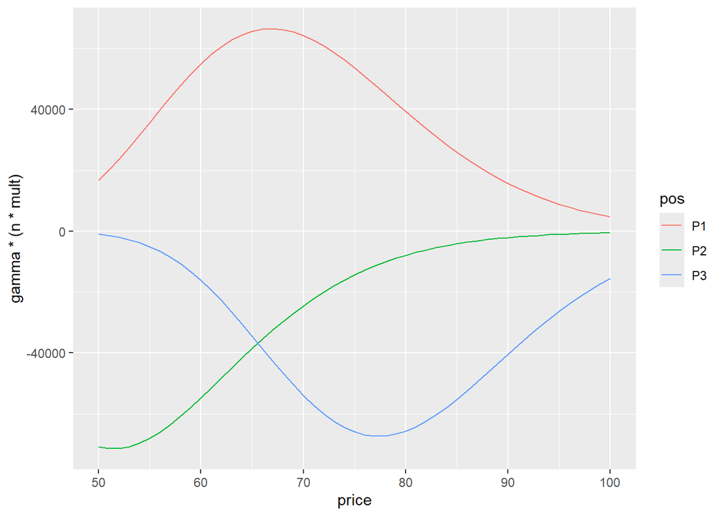

```r
port2 %>%
  ggplot() +
  geom_line(aes(x = price, y = gamma*(n*mult), color = pos))
```

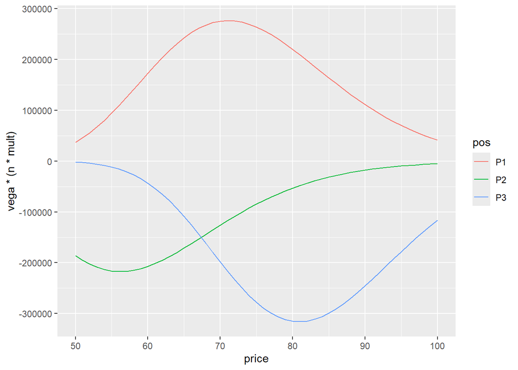

```r
port2 %>%
  ggplot() +
  geom_line(aes(x = price, y = vega*(n*mult), color = pos))
```

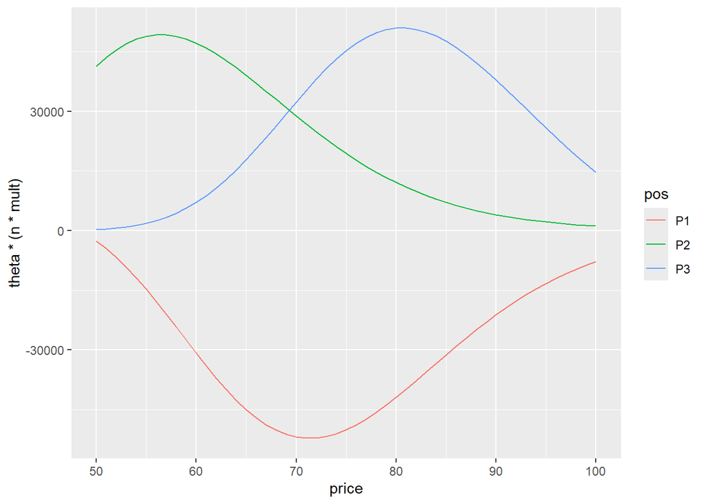

```r
port2 %>%
  ggplot() +
  geom_line(aes(x = price, y = theta*(n*mult), color = pos))
```

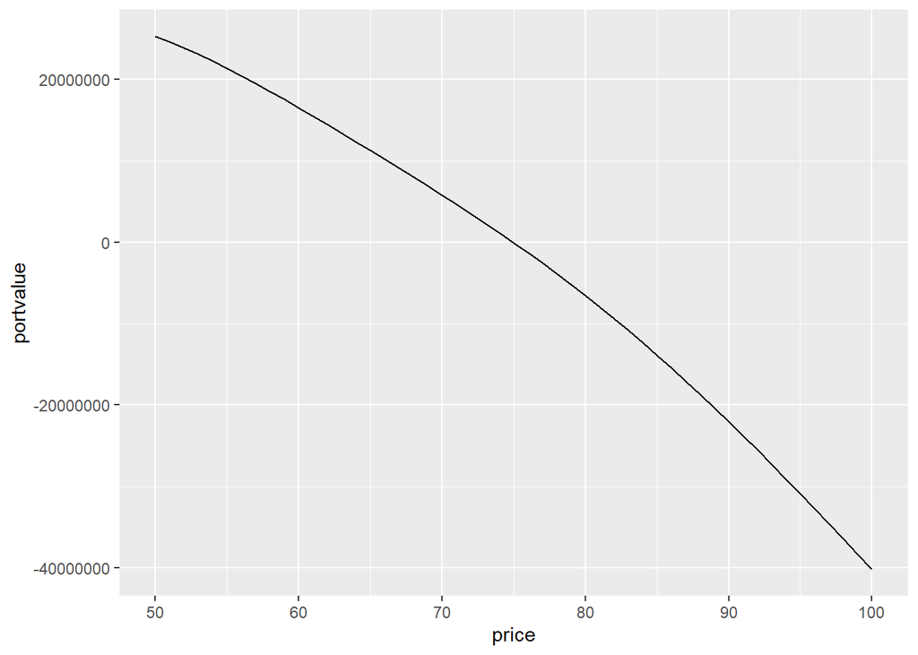

```r
#Will need to double check if these plots look right




#d. Portfolio mark to market value and gamma


#Going to just make a gbswrapper function (like class notes) to simplify mapply implementation
#I'll make it just return price to start but can modify later if needed
gbswrapper <- function(price, K, T2M, r, b, sigma, type) {
  RTL::GBSOption(price, K, T2M, r, b, sigma = sigma, type = type)$price
}



#Calculating the values for all options positions
port2 <- port2 %>%
  mutate(
    optvalue = mapply(gbswrapper, price, K, T2M, r, b = 0, sigma, type),
    posvalue = optvalue*n*mult)



#Creating portfolio value combining the individual positions
port4 <- port2 %>%
  group_by(price) %>%
  summarise(portvalue = sum(posvalue)) %>%
  ungroup()

port4 %>% ggplot() +
  geom_line(aes(x = price, y = portvalue))
```

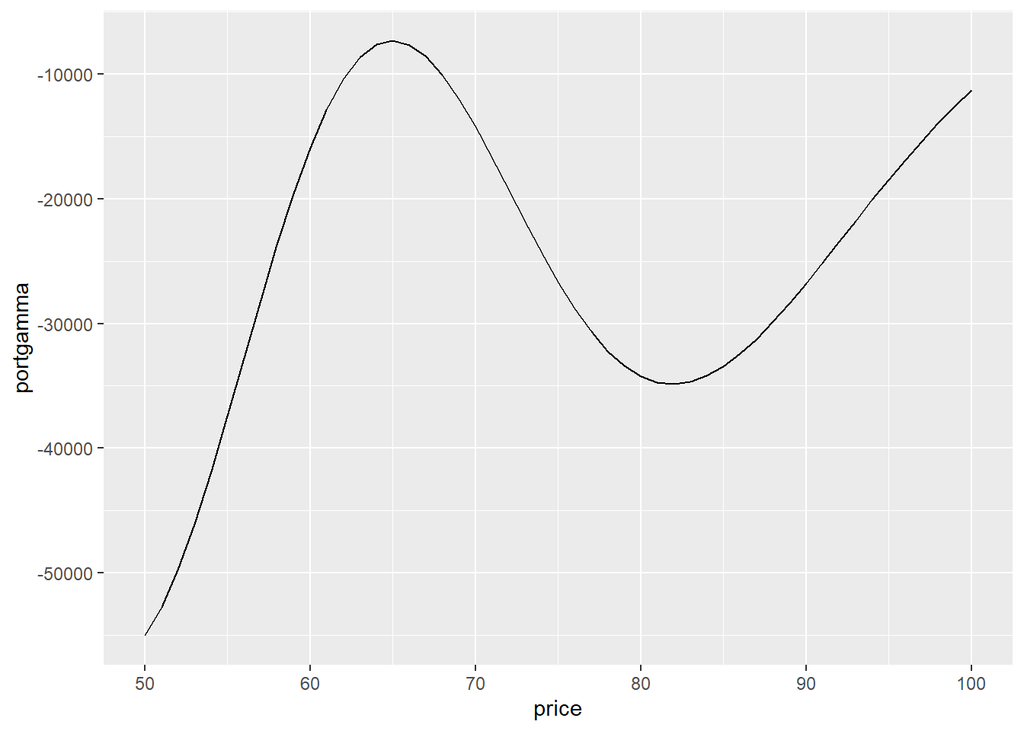

```r
port5 <- port2 %>%
  mutate(gammavalue = gamma*n*mult) %>%
  group_by(price) %>%
  summarise(portgamma = sum(gammavalue))

port5 %>% ggplot() +
  geom_line(aes(x = price, y = portgamma))
```

We can see the mark to market of the portfolio is downward sloping across the $50-100 range. This shows the portfolio is net short as increases in stock price decrease the value of our option portfolio. In terms of delta, this means the portfolio is delta negative overall, as delta can be represented as the slope of stock price vs options value. Although the value is decreasing across the price range it is not perfectly straight, which represents the impact of gamma (change in delta) on the portfolio.

Portfolio gamma is highest around $65, which is due to the long put with a strike price of $70, as we can see on gamma v price graph, broken down by position. Gamma is most negative in the low 50s and low 80s, this is where the short put at a strike of $55 and the short call at a strike of $80 pull the overall portfolio gamma down the most.

For a delta hedger rebalancing daily, this means that the rebalancing frequency would need to be the greatest in the most negative gamma regions as that is where the delta changes faster per $ price change, and the prior delta hedges put in place will no longer be covering delta exposure.

# Question 2 (3 points)

Sum Greeks across positions to show **portfolio-level Greeks** at the current market. Present in a `gt::gt()` table. At approximately what futures price does the portfolio delta change sign?

```r
#Sum greeks across positions to show portfolio level greeks
#Need to summarize the greeks for all price levels

#Numbers too high, need to check how I'm multiplying them by mult and n

port6 <- port2 %>%
  mutate(deltavalue = delta*n*mult) %>%
  mutate(gammavalue = gamma*n*mult) %>%
  mutate(vegavalue = vega*n*mult) %>%
  mutate(thetavalue = theta*n*mult) %>%
  group_by(price) %>%
  summarise(portdelta = sum(deltavalue),
            portgamma = sum(gammavalue),
            portvega = sum(vegavalue),
            porttheta = sum(thetavalue))




#port6 %>% ggplot(aes(x=price)) +
#  geom_line(aes(y = portdelta, color = "Delta")) +
#  geom_line(aes(y = portgamma, color = "Gamma")) +
#  geom_line(aes(y = portvega, color = "Vega")) +
#  geom_line(aes(y = porttheta, color = "Theta"))



#I am interpreting this as just showing the portfolio greeks at F_0 which is 73
#port6 has the portfolio greeks for all prices

port6 %>%
  gt() %>%
  fmt_number(
    decimals = 2,
    use_seps = TRUE
  ) %>%
  cols_label(
    price = "Price",
    portdelta = "Delta",
    portgamma = "Gamma",
    portvega = "Vega",
    porttheta = "Theta"
  ) %>%
  tab_header(
    title = "Portfolio Greeks for F = 50-100"
    )
```

Portfolio Greeks for F = 50-100

| Price | Delta | Gamma | Vega | Theta |
| --- | --- | --- | --- | --- |
| 50.00 | −656,345.65 | −55,012.22 | −151,005.42 | 38,952.44 |
| 51.00 | −710,287.73 | −52,739.09 | −152,082.88 | 39,421.91 |
| 52.00 | −761,570.79 | −49,711.61 | −150,749.52 | 39,350.43 |
| 53.00 | −809,498.10 | −46,049.54 | −147,044.14 | 38,738.54 |
| 54.00 | −853,505.33 | −41,896.87 | −141,109.32 | 37,608.29 |
| 55.00 | −893,181.41 | −37,414.87 | −133,186.78 | 36,002.43 |
| 56.00 | −928,281.93 | −32,774.29 | −123,607.37 | 33,982.41 |
| 57.00 | −958,734.61 | −28,147.29 | −112,776.09 | 31,625.54 |
| 58.00 | −984,636.74 | −23,699.60 | −101,153.04 | 29,021.23 |
| 59.00 | −1,006,245.01 | −19,583.18 | −89,231.43 | 26,266.73 |
| 60.00 | −1,023,958.56 | −15,929.99 | −77,514.11 | 23,462.62 |
| 61.00 | −1,038,296.33 | −12,846.99 | −66,489.81 | 20,708.11 |
| 62.00 | −1,049,870.18 | −10,412.67 | −56,610.64 | 18,096.71 |
| 63.00 | −1,059,355.45 | −8,675.21 | −48,272.08 | 15,712.28 |
| 64.00 | −1,067,460.29 | −7,652.25 | −41,796.49 | 13,625.73 |
| 65.00 | −1,074,895.70 | −7,332.15 | −37,420.93 | 11,892.61 |
| 66.00 | −1,082,347.46 | −7,676.58 | −35,289.75 | 10,551.45 |
| 67.00 | −1,090,451.13 | −8,624.18 | −35,452.23 | 9,623.15 |
| 68.00 | −1,099,771.25 | −10,095.02 | −37,864.81 | 9,111.18 |
| 69.00 | −1,110,785.18 | −11,995.48 | −42,397.78 | 9,002.60 |
| 70.00 | −1,123,871.94 | −14,223.35 | −48,845.57 | 9,269.77 |
| 71.00 | −1,139,306.10 | −16,672.78 | −56,939.84 | 9,872.63 |
| 72.00 | −1,157,256.51 | −19,238.85 | −66,364.52 | 10,761.27 |
| 73.00 | −1,177,789.31 | −21,821.67 | −76,771.74 | 11,878.81 |
| 74.00 | −1,200,874.70 | −24,329.76 | −87,797.84 | 13,164.22 |
| 75.00 | −1,226,396.67 | −26,682.59 | −99,078.72 | 14,555.10 |
| 76.00 | −1,254,165.03 | −28,812.48 | −110,263.62 | 15,990.19 |
| 77.00 | −1,283,928.77 | −30,665.62 | −121,027.12 | 17,411.61 |
| 78.00 | −1,315,390.15 | −32,202.41 | −131,078.77 | 18,766.65 |
| 79.00 | −1,348,218.86 | −33,397.16 | −140,170.26 | 20,009.19 |
| 80.00 | −1,382,065.54 | −34,237.30 | −148,100.16 | 21,100.63 |
| 81.00 | −1,416,574.33 | −34,722.17 | −154,716.20 | 22,010.47 |
| 82.00 | −1,451,394.01 | −34,861.47 | −159,915.40 | 22,716.43 |
| 83.00 | −1,486,187.61 | −34,673.64 | −163,642.26 | 23,204.31 |
| 84.00 | −1,520,640.14 | −34,184.03 | −165,885.48 | 23,467.46 |
| 85.00 | −1,554,464.75 | −33,423.16 | −166,673.31 | 23,506.15 |
| 86.00 | −1,587,406.99 | −32,425.10 | −166,068.25 | 23,326.69 |
| 87.00 | −1,619,247.55 | −31,225.84 | −164,161.12 | 22,940.50 |
| 88.00 | −1,649,803.54 | −29,862.00 | −161,064.96 | 22,363.07 |
| 89.00 | −1,678,928.50 | −28,369.63 | −156,909.08 | 21,613.04 |
| 90.00 | −1,706,511.33 | −26,783.26 | −151,833.33 | 20,711.16 |
| 91.00 | −1,732,474.37 | −25,135.17 | −145,982.90 | 19,679.47 |
| 92.00 | −1,756,770.88 | −23,454.81 | −139,503.69 | 18,540.48 |
| 93.00 | −1,779,382.02 | −21,768.47 | −132,538.34 | 17,316.48 |
| 94.00 | −1,800,313.54 | −20,099.07 | −125,222.97 | 16,028.98 |
| 95.00 | −1,819,592.40 | −18,466.07 | −117,684.64 | 14,698.25 |
| 96.00 | −1,837,263.31 | −16,885.57 | −110,039.45 | 13,342.97 |
| 97.00 | −1,853,385.46 | −15,370.42 | −102,391.29 | 11,979.98 |
| 98.00 | −1,868,029.37 | −13,930.45 | −94,831.09 | 10,624.18 |
| 99.00 | −1,881,273.95 | −12,572.74 | −87,436.65 | 9,288.39 |
| 100.00 | −1,893,203.98 | −11,301.91 | −80,272.78 | 7,983.41 |

```r
port6 %>%
  filter(price == F_0) %>%
  gt() %>%
  fmt_number(
    decimals = 2,
    use_seps = TRUE
  ) %>%
  cols_label(
    price = "Price",
    portdelta = "Delta",
    portgamma = "Gamma",
    portvega = "Vega",
    porttheta = "Theta"
  ) %>%
  tab_header(
    title = "Portfolio Greeks at Current Market"
    )
```

Portfolio Greeks at Current Market

| Price | Delta | Gamma | Vega | Theta |
| --- | --- | --- | --- | --- |
| 73.00 | −1,177,789.31 | −21,821.67 | −76,771.74 | 11,878.81 |

```r
#Have determined through changing the price range, and considering the nature of the portfolio that delta will never be positive, it is a delta negative portfolio
```

Through changing the price range, and considering the nature of the portfolio I don’t believe that delta will ever be positive, it is a delta negative portfolio. As the price approaches 0 the delta gets higher (closer to 0) but will not be positive at any real price level.

# Question 3 (8 points)

Overnight, US-Iran tensions escalate sharply. The US strikes Iranian nuclear facilities; Iran retaliates by mining the Strait of Hormuz. WTI gaps up at the open:

- WTI futures: F moves from **73.00** to **90.00** (+$17.00/bbl)
- Implied volatility: each position’s sigma spikes by **+0.20** (20 vol points)
- Time: **1 calendar day** passes

For each position and for the portfolio total, compute:

1. **Actual P&L**: full revaluation at new F, new sigma, new T. P&L = (new price − old price) × n × mult.
2. **Attributed P&L**: ΔV ≈ (Delta × ΔF) + (½ × Gamma × ΔF²) + (Vega × Δσ) + (Vanna × ΔF × Δσ) + (Theta × Δt), scaled to dollars.
3. **Unexplained residual**: Actual − Attributed.
4. **Attribution breakdown**: what share (%) of Attributed P&L comes from each Greek?

**Vanna** (∂²V/∂F∂σ) measures how delta changes as volatility moves. With both a large spot jump and a large vol spike coinciding, Vanna is non-negligible. Use a central-difference cross-partial:

$$\text{Vanna} = \frac{V(F+h, \sigma+k) - V(F+h, \sigma-k) - V(F-h, \sigma+k) + V(F-h, \sigma-k)}{4 \cdot h \cdot k}$$

with h = `step_S` and k = `step_v`. The Vanna P&L contribution is Vanna × ΔF × Δσ.

Present all results in a `gt::gt()` table. Which position dominates the loss? Is the Greek attribution a reliable approximation here, and why or why not?

```r
#port7 will be the three positions under new circumstances


changetime = 1/365
changesigma = 0.2
changef = 17

port7 <- port3 %>%
  select(pos, type, K, T2M, sigma, n, F_0) %>%
  mutate(T2M = T2M - changetime,
         sigma = sigma + changesigma,
         F_0 = F_0 + changef)


port7 <- port7 %>%
  mutate(
    optvalue = mapply(gbswrapper, F_0, K, T2M, r, b = 0, sigma, type),
    posvalue = optvalue*n*mult)


newportvalue = sum(port7$posvalue)



#port8 will be the three positions under old circumstances (stolen from port2)
port8 <- port2 %>%
  filter(price == 73)


oldportvalue = sum (port8$posvalue)



#Need function for Vanna
vannacalc <- function(price, K, T2M, r, b, sigma, type) {
  step_s = 1
  step_v = 0.01

  #four steps we need
  upsupv = RTL::GBSOption(price+step_s, K, T2M, r, b, sigma = sigma+step_v, type = type)$price
  upsdownv = RTL::GBSOption(price+step_s, K, T2M, r, b, sigma = sigma-step_v, type = type)$price
  downsupv = RTL::GBSOption(price-step_s, K, T2M, r, b, sigma = sigma+step_v, type = type)$price
  downsdownv = RTL::GBSOption(price-step_s, K, T2M, r, b, sigma = sigma-step_v, type = type)$price

  vanna = (((upsupv)-(upsdownv)-(downsupv)+(downsdownv))/(4*step_s*step_v))
  vanna

}



#Add vanna to port8
port8 <- port8 %>%
  mutate(vanna = mapply(vannacalc, price, K, T2M, r, b = 0, sigma, type))


#Contributions of each greek
port8 <- port8 %>%
  mutate(contdelta = delta*changef,
         contgamma = 0.5*gamma*changef^2,
         contvega = vega*changesigma,
         contvanna = vanna*changef*changesigma,
         conttheta = theta*changetime)


#Attributed option value and position value (which is option value scaled to $)

#This will just be the sum of each greeks contribution
port8 <- port8 %>%
  mutate(atriboptvalue = rowSums(across(c(contdelta, contgamma, contvega, conttheta, contvanna))))

#Then we multiply this column by n*mult to get the impact on the full position, taking into account long/short
port8 <- port8 %>%
  mutate(atriportvalue = atriboptvalue*n*mult)


actualPL = newportvalue - oldportvalue

atributedPL = sum(port8$atriportvalue)


unexplainedresid = actualPL - atributedPL



#Need to do the breakdown for each greek
#Will make a new table with just the greeks and positions then sum them up, divide them by total to get %

#Taking what we need and calculating the sum of each greek across the positions
#Then we will divide by total to get the attribution breakdown (4.)
port9 <- port8 %>%
  select(contdelta, contgamma, contvega, contvanna, conttheta, atriboptvalue) %>%
  add_row(
    contdelta = sum(port8$contdelta),
    contgamma = sum(port8$contgamma),
    contvega = sum(port8$contvega),
    contvanna = sum(port8$contvanna),
    conttheta = sum(port8$conttheta),
    atriboptvalue = sum(port8$atriboptvalue)
  )

totalcont <- port9[4,]

percentcont <- totalcont / totalcont$atriboptvalue






q3123 <- port8 %>%
  mutate(actualPL = (port7$optvalue - optvalue)*n*mult,
         attribPL = atriportvalue) %>%
  select(pos, actualPL, attribPL) %>%
  mutate(unexplained = actualPL - attribPL)



q3123 <- q3123 %>%
  add_row(pos = "port",
          actualPL = sum(q3123$actualPL, na.rm = TRUE),
          attribPL = sum(q3123$attribPL, na.rm = TRUE),
          unexplained = sum(q3123$actualPL, na.rm = TRUE) - sum(q3123$attribPL, na.rm = TRUE))


q3123 <- q3123 %>%
  rename(
    Position = pos,
    "Actual P&L" = actualPL,
    "Attributed P&L" = attribPL,
    "Unexplained" = unexplained
    )


q3123 %>% gt() %>%
  fmt_number(
    columns = -Position,
    decimals = 2,
    use_seps = TRUE
  )
```

| Position | Actual P&L | Attributed P&L | Unexplained |
| --- | --- | --- | --- |
| P1 | −3,037,480.34 | −5,091,143.71 | 2,053,663.37 |
| P2 | 81,871.37 | 2,612,401.78 | −2,530,530.41 |
| P3 | −24,618,902.01 | −24,355,893.86 | −263,008.15 |
| port | −27,574,510.98 | −26,834,635.78 | −739,875.20 |

```r
#Making a table to answer part 4, and presenting as gt as per instruction
q34 <- tibble(
  Greek = c("Delta", "Gamma", "Vega", "Vanna", "Theta", "Total"),
  Contribution = c(
    totalcont$contdelta,
    totalcont$contgamma,
    totalcont$contvega,
    totalcont$contvanna,
    totalcont$conttheta,
    totalcont$atriboptvalue),
  Percent = c(
    percentcont$contdelta,
    percentcont$contgamma,
    percentcont$contvega,
    percentcont$contvanna,
    percentcont$conttheta,
    percentcont$atriboptvalue
  ))



q34 %>%
  gt() %>%
  fmt_number(columns = Contribution, decimals = 2) %>%
  fmt_percent(columns = Percent, decimals = 2)
```

| Greek | Contribution | Percent |
| --- | --- | --- |
| Delta | −2.50 | −30.05% |
| Gamma | 10.05 | 120.65% |
| Vega | 0.06 | 0.75% |
| Vanna | 0.72 | 8.65% |
| Theta | 0.00 | −0.00% |
| Total | 8.33 | 100.00% |

Through our table we can see that P3 is the main driver for the loss by a large margin. P1 is much smaller and P2 is actually slighly positive.

Our attribution calculated is somewhat accurate although I don’t think it should be relied upon. The position errors are very large for 1 and 2 even though they cancel each other out at the portfolio level.

This is likely because the combined spot and volatility shocks are large, so higher-order nonlinear effects beyond the included greeks are important.

# Question 4 (4 points)

The Iran war scenario (ΔF = +$17) is an extreme move. How well does the Greek approximation hold as WTI moves further from the current market?

Holding vol and time constant at their initial values, compute Actual P&L (full revaluation) and Attributed P&L (Delta + Gamma only) for the portfolio across ΔF ∈ [–20, +20] in $1 increments.

**a.** Plot Actual, Attributed, and the Residual on the same chart. Mark the Iran war move (ΔF = +17) with a vertical line.

**b.** At what ΔF does the absolute residual first exceed 5% of the absolute Actual P&L? Report in a `gt::gt()` table. What does this tell you about using Greeks for risk management in extreme scenarios?

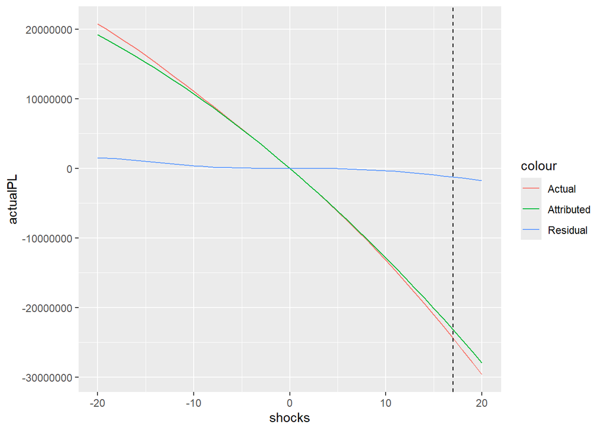

```r
#Compute actual and attributed (Delta+Gamma only) PL for the portfolio across a range

baseq4 <- port8 %>% select(price:gamma, optvalue)

pricesq4 <- tibble(shocks = seq(-20,20))

#Setting up the PL df with prices ranged from -20 to +20 from the current price
PLq4 <- baseq4 %>%
  crossing(pricesq4) %>%
  mutate(newprice = price + shocks) %>%
  relocate(newprice, .before = 1) %>%
  select(-price) %>%
  arrange(newprice)


#Actual option value at all prices
PLq4 <- PLq4 %>%
  mutate(newactual = mapply(
    gbswrapper, price = newprice, K, T2M, r, b = 0, sigma = sigma, type = type
  ))



#Computing actual and attributed PL
PLq4 <- PLq4 %>%
  mutate(
    actualPL = (newactual - optvalue)*n*mult,
    attribPL = ((delta * shocks) + (0.5 * gamma * shocks^2))*n*mult
  )


#For the full portfolio
PortPLq4 <- PLq4 %>%
  group_by(shocks)%>%
  summarise(
    actualPL = sum(actualPL),
    attribPL = sum(attribPL),
    residual = sum(actualPL) - sum(attribPL))



#Plot
PortPLq4 %>% ggplot(aes(x = shocks)) +
  geom_line(aes(y = actualPL, color = "Actual")) +
  geom_line(aes(y = attribPL, color = "Attributed")) +
  geom_line(aes(y = residual, color = "Residual")) +
  geom_vline(xintercept = 17, linetype = "dashed")
```

```r
#Q4 b.


PortPLq4 <- PortPLq4 %>%
  filter(shocks != 0) %>%
  mutate(resid_pct = abs(residual) / abs(actualPL))



PortPLq4 %>%
  filter(resid_pct > 0.05) %>%
  arrange(abs(shocks)) %>%
  slice(1) %>%
  gt() %>%
  fmt_number(decimals = 2)
```

| shocks | actualPL | attribPL | residual | resid_pct |
| --- | --- | --- | --- | --- |
| −13.00 | 14,194,039.80 | 13,467,329.71 | 726,710.10 | 0.05 |

This suggests that delta gamma approximation is reasonably accurate for local or more typical price movements, but deviate more as the price shocks get more extreme.

In extreme scenarios the higher order non linearities matter more, meaning we should go for a full revaluation rather than relying on the greeks.

# Question 5 (6 points)

Discuss the key learnings and insights from a Greek risk management perspective. Your explanation must:

- Interpret the **full revaluation MTM profile** from Q1(d): describe the portfolio’s curvature structure across the $50–$100 range. Identify the regions of maximum and minimum Gamma. Explain what the changing Gamma means for a desk running this portfolio — specifically, how frequently delta rebalancing is needed as WTI moves through the strikes.
- Interpret the **full revaluation P&L and Gamma profiles** from Q1(d): describe the portfolio’s curvature structure and identify which positions drive positive vs negative Gamma regions.
- Identify which position and which Greek drove the largest loss in the Iran war scenario, and explain why that was predictable from the portfolio structure.
- Explain the role of **Vanna**: why is it non-trivial when both a large spot jump and a large vol spike occur simultaneously?
- Explain why the Greek approximation (Q4) breaks down at extreme moves, and what this means for a real desk managing this book.

Pay particular attention to why textbook delta-hedging assumptions break down in geopolitical gap scenarios, and what risk tools a real energy desk would use instead.

The mark-to-market profile slopes downward across our range of $50-$100 which indicates the portfolio is Delta negative and loses value as WTI futures rise. The curve is nonlinear due to changing Gamma across strikes. Gamma is least negative around the mid $60s where the long 70 put adds convexity, and most negative near the short option strikes. As WTI moves through those regions, Delta will change faster, requiring more frequent hedge rebalancing.

The long 70 put contributes positive Gamma near its strike, while the short 55 put and short 80 call contribute negative Gamma. Because the short options dominate, the portfolio is net short Gamma across most prices, producing a concave PL profile where losses accelerate as the underlying moves further from the initial price.

Vanna measures how Delta changes when volatility moves, when the underlying price and volatility both shift, an additional interaction effect appears in PL that is not captured by Delta or Vega. This interaction means some PL cannot be explained by Delta or Vega individually, making Vanna important in scenarios where both spot and volatility experience significant shocks.

Greek approximations are local Taylor expansions around the current state of the market. Because of this, they work best for small moves near the point where the Greeks were calculated. In a large shock relative to expectations like the $17 move in WTI, the portfolio moves far from that point, so higher order nonlinear effects become meaningful. This leads to an increase in the difference between actual PL and the Greek attributed PL and the residual grows as shocks become larger.

Delta hedging assumes continuous trading and relatively small price movements so that positions can be rebalanced frequently. During geopolitical shocks, prices can gap before hedges can be adjusted. When this occurs the hedge cannot respond in time, which leaves the portfolio exposed to risk. Because of this, trading desks would rely more on methods like stress testing and scenario analysis rather than depending on delta hedging.